# AP-4209 ESIEE-Paris: 2025 - 2026

Fouille de données

PROJET 3 : CLASSIFICATION BAYÉSIENNE ET ANALYSE FACTORIELLE DISCRIMINANTE

– Classification des Thèses de Doctorat Françaises –

Auteurs : Meliana ZERROUG, Keren BENADIBA– ESIEE Paris

### 2. Méthodologie

#### 2.1 Chargement des données

Nous utilisons donc le jeu de données des thèses françaises. Nous allons donc d’abord charger les bibliothèques nécessaires.

- **Installation des packages nécessaires :**

```r
# Définir un miroir CRAN
options(repos = c(CRAN = "https://cloud.r-project.org/"))

if(!require("dplyr")) install.packages("dplyr")
if(!require("kableExtra")) install.packages("kableExtra")
if(!require("tm")) install.packages("tm")
if(!require("MASS")) install.packages("MASS")
if(!require("e1071")) install.packages("e1071")
if(!require("topicmodels")) install.packages("topicmodels")
if(!require("caret")) install.packages("caret")
if(!require("stopwords")) install.packages("stopwords")
if(!require("naivebayes")) install.packages("naivebayes")
if(!require("ggplot2")) install.packages("ggplot2")
```

- **Chargement des packages nécessaires :**

```r
library(dplyr)
library(kableExtra)
library(tm)
library(MASS)
library(e1071)
library(topicmodels)
library(caret)
library(stopwords)
library(naivebayes)
library(stopwords)
library(ggplot2)
```

- **Première étape :**

```r
file.remove("THESE_DATASET.Rda")
```

```
## [1] FALSE
```

```r
file.remove("THESE_CLEAN.Rda")
```

```
## [1] TRUE
```

```r
rm(list = ls())
```

- **Seconde étape :**

```r
# Update this path to match your actual file location
csv_file <- "french_thesis_20231021_metadata.csv"
df_temp <- read.csv(csv_file)
save(df_temp, file = "THESE_DATASET.Rda")
```

- **Troisième étape :**

```r
rm(df_temp)
rm(list = ls())
load("THESE_DATASET.Rda")
colnames(df_temp)
```

```
## [1] "URL"         "Title"       "Author"      "Description" "Direction"
## [6] "Domain"      "Statuts"     "Date"
```

```r
head(df_temp)
```

```
##            URL
## 1 1971PAUU3003
## 2 1972PAUU3002
## 3 1973NAN10113
## 4 1976PAUU3001
## 5       s66414
## 6 1993PA100148
##                                                                                                                                                       Title
## 1                                                                                                      Noyaux salins hygroscopiques et sursaturation saline
## 2 Contribution à l'étude de l'évolution des propriétés diélectriques d'échantillons obtenus par solidification de solutions aqueuses de chlorure d'ammonium
## 3                                                                                                                                           Lymphocytologie
## 4       Etude théorique des systèmes électroniques à couches ouvertes : application à l'étude photochimique de la cycloaddition du méthylène sur l'éthylène
## 5                                                                                   Le personnel diplomatique francais sous la revolution de 1789 a   1799.
## 6                                                     Les miracles de l'Évêque Jean Michel et le culte des saints dans le Diocèse d'Angers v. 1370- v. 1560
##                    Author
```

[output cut: 27 more lines]

- **Vérification du nombre de descriptions vides :**

```r
nb_vide <- sum(df_temp$Description == "")
nb_na <- sum(is.na(df_temp$Description))

total_lignes <- nrow(df_temp)
total_inutiles <- nb_vide + nb_na

cat("Nombre total de lignes :", total_lignes, "\n")
```

```
## Nombre total de lignes : 519578
```

```r
cat("--- \n")
cat("Total à supprimer :", total_inutiles, "\n")
```

```
## Total à supprimer : 105025
```

- **Quatrième étape :**

```r
df_clean <- df_temp %>%
  dplyr::rename(Subject = Domain,
                Texte = Description) %>%
  dplyr::select(Subject, Texte)

#On va enlever les lignes vides car il y a quelques descriptions vides

df_clean <- df_clean %>%
  filter(!is.na(Texte) & Texte != "" & Texte != " ")

cat("Nombre de lignes après le nettoyage : ", nrow(df_clean), "\n")
```

```
## Nombre de lignes après le nettoyage :  414553
```

```r
set.seed(123)
df_clean <- df_clean %>%
            sample_n(5000)  # Réduire à 5000 pour une exécution plus rapide

kable(head(df_clean), caption = "Jeu de données") %>%
  kable_styling(bootstrap_options = c("striped", "hover", "condensed"), full_width = F, position = "center")%>%
  scroll_box( height = "200px")
```

Jeu de données

| Subject | Texte |
| --- | --- |
| Génie des procédés et de l’environnement | La miniaturisation est une voie d’intensification pour la mise en oeuvre de procédés limités par les transferts thermique ou massique. La particularité des appareils micro-structurés vient en premier … |
| Informatique | Cette thèse traite de la modélisation des systèmes temps-réel à l’aide de réseaux de Petri. Nous considérons séparément la question de représentation du temps et celle de la préemption (interruption d… |
| Biologie | Pour obtenir des plantes resistantes aux inhibiteurs de l’hydroxyphenylpyruvate dioxygenase (hppd), nous avons souhaite construire une voie metabolique contournant l’hppd en introduisant les genes cod… |
| Épidémiologie | L’asthme est un problème de santé publique compte tenu de ses conséquences cliniques et des dépenses qu’il occasionne. A partir des données de trois études épidémiologiques, nous avons étudié la prise… |
| Réseaux, Télécommunications, Systèmes et Architecture (RTSA) | Cette thèse est dédié à l’étude de la problématique des interférences multi utilisateurs dans le système Argos et à la proposition des diverses techniques pour réduire les effets de ces interférences.… |
| Sciences de l’éducation | Titre du projet de thèse: «Le système éducatif pluraliste au Pakistan crée-t-il et renforce-t-il la structure de classe oppressive dans la société en général: une étude de cas de Pendjab» Problème, ob… |

- **Regroupement des thèmes en catégories principales :**

```r
# Créer une fonction pour regrouper les thèmes similaires
regroup_subjects <- function(subject) {
  subject <- tolower(subject)

  # Ordre d'importance : être plus spécifique d'abord
  if (grepl("biologie|écologie|environnement|biodiversité|organisme|cellulaire|moléculaire|terre|géologie|océan|espace|atmosphère|climat|toxicologie|médecine|pharmacologie|neurosciences|oncologie|épidémiologie|cancérologie", subject)) {
    return("Biologie et Sciences de la Vie")
  } else if (grepl("chimie|physique|matériaux|minérale|organique|analytique|énergétique", subject)) {
    return("Chimie et Physique")
  } else if (grepl("informatique|numérique|signal|communication|télécommunication|électronique", subject)) {
    return("Informatique et Télécommunications")
  } else if (grepl("génie|ingénieur|technologie|civil|mécanique|électrique|énergie|fluide|dynamique", subject)) {
    return("Génie et Technologie")
  } else if (grepl("droit|juridique|science.*politique|politique|gouvernement|constitution|public|privé|international|criminel", subject)) {
    return("Droit et Sciences Politiques")
  } else if (grepl("mathématique|statistique|probabilité", subject)) {
    return("Mathématiques et Statistiques")
  } else if (grepl("histoire|archéologie|littérature|langue|étude|germaniques|anglaises|italienne|latino|nord-américain|cinéma", subject)) {
    return("Histoire et Lettres")
  } else if (grepl("anthropologie|sociologie|psychologie|sciences.*humaines|ethnologie|sport|mouvement|éducation|formation|pédagogie|apprentissage|enseignement", subject)) {
    return("Sciences Humaines et Sociales")
  } else {
    # Si on arrive ici, on essaie de capturer des éléments génériques
    if (grepl("science", subject)) {
      return("Sciences générales")
    }
    return("Sciences générales")  # Plutôt que "Autres"
  }
}

# Appliquer le regroupement
df_clean$Subject <- sapply(df_clean$Subject, regroup_subjects)

# Afficher la nouvelle distribution
table_subjects <- table(df_clean$Subject)
cat("\nDistribution des catégories :\n")
```

```
##
## Distribution des catégories :
```

```r
print(table_subjects)
```

```
##
##     Biologie et Sciences de la Vie                 Chimie et Physique
##                                673                                826
##       Droit et Sciences Politiques               Génie et Technologie
##                                330                                393
##                Histoire et Lettres Informatique et Télécommunications
##                                461                                444
##      Mathématiques et Statistiques                 Sciences générales
##                                158                               1308
##      Sciences Humaines et Sociales
##                                407
```

```r
# Garder seulement les catégories avec au moins 50 documents
df_clean <- df_clean %>%
  filter(Subject %in% names(table_subjects)[table_subjects >= 50])

cat("\nNombre total après filtrage :", nrow(df_clean), "\n")
```

```
##
## Nombre total après filtrage : 5000
```

```r
cat("Nombre de catégories :", length(unique(df_clean$Subject)), "\n")
```

```
## Nombre de catégories : 9
```

```r
cat("\nDistribution finale :\n")
```

```
##
## Distribution finale :
```

```r
print(table(df_clean$Subject))
```

```
##
##     Biologie et Sciences de la Vie                 Chimie et Physique
##                                673                                826
##       Droit et Sciences Politiques               Génie et Technologie
##                                330                                393
##                Histoire et Lettres Informatique et Télécommunications
##                                461                                444
##      Mathématiques et Statistiques                 Sciences générales
##                                158                               1308
##      Sciences Humaines et Sociales
##                                407
```

- **Cinquième étape :**

```r
#On va maintenant enregistrer le nouveau dataframe et on nettoie

save(df_clean, file = "THESE_CLEAN.Rda")
rm(df_clean, df_temp)
file.remove("THESE_DATASET.Rda")
```

```
## [1] TRUE
```

- **Sixième étape :**

```r
#On charge le nouveau jeu de données
rm(list = ls())
load("THESE_CLEAN.Rda")
colnames(df_clean)
```

```
## [1] "Subject" "Texte"
```

- **Septième étape :**

```r
#Présentation des données finales

kable(head(df_clean), caption = "Jeu de données") %>%
  kable_styling(bootstrap_options = c("striped", "hover", "condensed"), full_width = F, position = "center")%>%
  scroll_box( height = "200px")
```

Jeu de données

| Subject | Texte |
| --- | --- |
| Biologie et Sciences de la Vie | La miniaturisation est une voie d’intensification pour la mise en oeuvre de procédés limités par les transferts thermique ou massique. La particularité des appareils micro-structurés vient en premier … |
| Informatique et Télécommunications | Cette thèse traite de la modélisation des systèmes temps-réel à l’aide de réseaux de Petri. Nous considérons séparément la question de représentation du temps et celle de la préemption (interruption d… |
| Biologie et Sciences de la Vie | Pour obtenir des plantes resistantes aux inhibiteurs de l’hydroxyphenylpyruvate dioxygenase (hppd), nous avons souhaite construire une voie metabolique contournant l’hppd en introduisant les genes cod… |
| Biologie et Sciences de la Vie | L’asthme est un problème de santé publique compte tenu de ses conséquences cliniques et des dépenses qu’il occasionne. A partir des données de trois études épidémiologiques, nous avons étudié la prise… |
| Informatique et Télécommunications | Cette thèse est dédié à l’étude de la problématique des interférences multi utilisateurs dans le système Argos et à la proposition des diverses techniques pour réduire les effets de ces interférences.… |
| Sciences Humaines et Sociales | Titre du projet de thèse: «Le système éducatif pluraliste au Pakistan crée-t-il et renforce-t-il la structure de classe oppressive dans la société en général: une étude de cas de Pendjab» Problème, ob… |

#### 2.2 Préparation pour l’AFD et le Bayésien (NLP)

Maintenant on va passer au traitement du texte. L’objectif va être de transformer les résumés en données numériques. Contrairement au mini projet 2 (Twitter), nous devions traiter de l’anglais, ici nous allons devoir traiter du français donc il va falloir gérer les accents et des mots vides différents.

```r
# Charger les stopwords français
suppressWarnings({
  stopwords_fr <- stopwords::stopwords("fr")
})

# Créer un corpus à partir des textes
corpus <- Corpus(VectorSource(df_clean$Texte))

# Nettoyage du texte
corpus <- corpus %>%
  tm_map(content_transformer(tolower)) %>%           # Convertir en minuscules
  tm_map(content_transformer(function(x) iconv(x, from = "UTF-8", to = "ASCII//TRANSLIT"))) %>%  # Supprimer les accents
  tm_map(removePunctuation) %>%                       # Supprimer la ponctuation
  tm_map(removeNumbers) %>%                           # Supprimer les chiffres
  tm_map(stripWhitespace) %>%                         # Supprimer les espaces superflus
  tm_map(removeWords, stopwords_fr)                   # Supprimer les stopwords français

# Créer une matrice document-terme (DTM)
dtm <- DocumentTermMatrix(corpus)

# Supprimer les termes très rares (qui apparaissent dans moins de 0.1% des documents)
sparse_threshold <- 0.999
dtm_reduced <- removeSparseTerms(dtm, sparse_threshold)

# Convertir en matrice dense pour les analyses
data_matrix <- as.matrix(dtm_reduced)

cat("Dimensions de la matrice document-terme :", nrow(data_matrix), "x", ncol(data_matrix), "\n")
```

```
## Dimensions de la matrice document-terme : 5000 x 11584
```

- **Vectorisation TF-IDF :**

```r
# Créer une matrice TF-IDF
tfidf_matrix <- weightTfIdf(dtm_reduced)
tfidf_data <- as.matrix(tfidf_matrix)

cat("Dimensions de la matrice TF-IDF :", nrow(tfidf_data), "x", ncol(tfidf_data), "\n")
```

```
## Dimensions de la matrice TF-IDF : 5000 x 11584
```

```r
cat("Nombre de termes uniques :", ncol(tfidf_data), "\n")
```

```
## Nombre de termes uniques : 11584
```

- **Sélection des termes les plus importants :**

```r
# Calculer la variance de chaque terme et sélectionner les tops
variances <- apply(tfidf_data, 2, var)
top_indices <- order(variances, decreasing = TRUE)[1:min(200, length(variances))]
tfidf_data_reduced <- tfidf_data[, top_indices]

cat("Dimensions après réduction :", nrow(tfidf_data_reduced), "x", ncol(tfidf_data_reduced), "\n")
```

```
## Dimensions après réduction : 5000 x 200
```

- **Combinaison avec la variable cible :**

```r
# Créer un dataframe avec les données TF-IDF réduites et la variable cible
df_features <- data.frame(
  Subject = df_clean$Subject,
  as.data.frame(tfidf_data_reduced)
)

# Afficher les dimensions
cat("Dimensions du dataset avec features TF-IDF :", nrow(df_features), "x", ncol(df_features), "\n")
```

```
## Dimensions du dataset avec features TF-IDF : 5000 x 201
```

```r
# Afficher la distribution des classes
table_dist <- table(df_features$Subject)
cat("\nDistribution des classes :\n")
```

```
##
## Distribution des classes :
```

```r
print(table_dist)
```

```
##
##     Biologie et Sciences de la Vie                 Chimie et Physique
##                                673                                826
##       Droit et Sciences Politiques               Génie et Technologie
##                                330                                393
##                Histoire et Lettres Informatique et Télécommunications
##                                461                                444
##      Mathématiques et Statistiques                 Sciences générales
##                                158                               1308
##      Sciences Humaines et Sociales
##                                407
```

#### 2.3 Analyse Factorielle Discriminante (AFD)

L’Analyse Factorielle Discriminante est une technique de réduction de dimensionnalité supervisée qui cherche à maximiser la séparation entre les classes. Elle crée de nouvelles variables (axes discriminants) qui sont les meilleures combinaisons linéaires des variables originales pour distinguer les différentes classes.

```r
# Sélectionner uniquement les variables numériques (termes TF-IDF)
X <- df_features[, -1]
y <- df_features$Subject

# Appliquer l'AFD
lda_model <- MASS::lda(X, grouping = y)

# Afficher les informations du modèle
cat("Nombre d'axes discriminants :", length(lda_model$svd), "\n")
```

```
## Nombre d'axes discriminants : 8
```

```r
cat("Proportions de la variance expliquée :\n")
```

```
## Proportions de la variance expliquée :
```

```r
print(lda_model$svd^2 / sum(lda_model$svd^2))
```

```
## [1] 0.37526893 0.18049718 0.14522850 0.12299776 0.07453722 0.04132140 0.03363225
## [8] 0.02651676
```

```r
# Obtenir les scores des axes discriminants
lda_scores <- predict(lda_model, X)$x

# Créer un dataframe avec les scores et la classe
df_lda <- data.frame(
  Subject = y,
  lda_scores
)

cat("Dimensions des données après AFD :", nrow(df_lda), "x", ncol(df_lda), "\n")
```

```
## Dimensions des données après AFD : 5000 x 9
```

```r
# Créer un tableau récapitulatif des résultats de l'AFD avec tests de Wilks
n_axes <- min(2, length(lda_model$svd))  # Prendre max 2 axes pour le tableau
result_afd <- matrix(0, nrow = n_axes, ncol = 6)

# Valeurs propres
result_afd[, 1] <- lda_model$svd[1:n_axes]^2

# Pourcentage d'inertie
result_afd[, 2] <- (lda_model$svd[1:n_axes]^2 / sum(lda_model$svd^2)) * 100

# Corrélations canoniques
result_afd[, 3] <- sqrt(lda_model$svd[1:n_axes]^2 / (1 + lda_model$svd[1:n_axes]^2))

# Wilks Lambda
result_afd[, 4] <- cumprod(1 - result_afd[, 3]^2)

# Khi-deux
N <- nrow(X)
P <- ncol(X)
K <- length(unique(y))
result_afd[, 5] <- -(N - (P + K)/2 - 1) * log(result_afd[, 4])

# p-value
result_afd[, 6] <- 1 - pchisq(result_afd[, 5], P * (K - 1))

result_afd_df <- data.frame(result_afd)
colnames(result_afd_df) <- c("Valeur propre", "% Inertie", "Corrélation", "Wilks Lambda", "Khi-deux", "p-value")
rownames(result_afd_df) <- paste0("Axe ", 1:n_axes)

kable(result_afd_df, caption = "Tests de Wilks") %>%
  kable_styling(bootstrap_options = c("striped", "hover", "condensed"), full_width = F, position = "center")%>%
  scroll_box( height = "200px")
```

Tests de Wilks

|  | Valeur propre | % Inertie | Corrélation | Wilks Lambda | Khi-deux | p-value |
| --- | --- | --- | --- | --- | --- | --- |
| Axe 1 | 725.7870 | 37.52689 | 0.9993118 | 0.0013759 | 32248.07 | 0 |
| Axe 2 | 349.0897 | 18.04972 | 0.9985708 | 0.0000039 | 60920.97 | 0 |

- **Visualisation avec ggplot2 (centres de gravité) :**

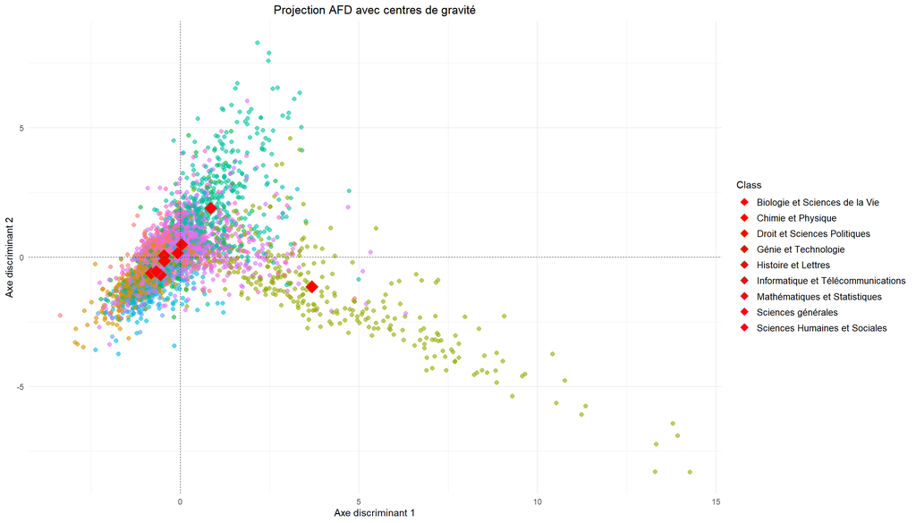

```r
# Créer un dataframe pour ggplot2
plot_data_gg <- data.frame(
  LD1 = lda_scores[, 1],
  LD2 = lda_scores[, 2],
  Class = y
)

# Calculer les centres de gravité de chaque classe
centers <- aggregate(cbind(LD1, LD2) ~ Class, data = plot_data_gg, mean)

# Créer le graphique avec ggplot2
ggplot(plot_data_gg, aes(x = LD1, y = LD2, colour = Class)) +
  geom_point(size = 2, alpha = 0.6) +
  geom_point(data = centers, aes(x = LD1, y = LD2, colour = Class),
             shape = 23, size = 5, fill = "red") +  # Centres en losange rouge
  geom_hline(yintercept = 0, size = 0.1, colour = 'black', linetype = "dashed") +
  geom_vline(xintercept = 0, size = 0.1, colour = 'black', linetype = "dashed") +
  theme_minimal() +
  ggtitle("Projection AFD avec centres de gravité") +
  xlab("Axe discriminant 1") +
  ylab("Axe discriminant 2") +
  theme(
    legend.position = "right",
    legend.text = element_text(size = 10),
    legend.title = element_text(size = 11),
    plot.title = element_text(size = 13, hjust = 0.5),
    axis.title = element_text(size = 11)
  ) +
  guides(colour = guide_legend(ncol = 1, override.aes = list(size = 3)))
```

### 3. Classification Bayésienne Naïve

Nous passons maintenant à l’une des dernières étapes, l’objectif est de prédire la discipline de la thèse en utilisant les informations condensées par l’AFD.

Pour cela, nous allons utiliser les scores factoriels (colonnes contenues dans notre tableau df_lda). Nous allons appliquer le théorème de Bayes sur les composantes de l’AFD. L’utilisation des axes de l’AFD est idéale car ils sont orthogonaux, ce qui respecte l’hypothèse d’indépendance du classifieur Bayésien Naïf.

Pour évaluer notre modèle nous n’allons pas juste faire le découpage habituel apprentissage / Test, nous allons utiliser la validation croisée. Cela veut donc dire qu’on va découper nos données en 10 parts égales. La machine va ensuite entrainer le modèle sur 9 parts et le tester sur la dernière et elle va répéter l’opération 10 fois en changeant la part de test pour chaque tour. Cela va permettre d’avoir une estimation beaucoup plus fiable du modèle.

```r
df_lda$Subject <- as.factor(df_lda$Subject)

# On renomme les catégories pour éviter les erreurs
levels(df_lda$Subject) <- make.names(levels(df_lda$Subject))

set.seed(123)
train_control <- trainControl(
  method = "cv",
  number = 10,
  savePredictions = "final",
  classProbs = TRUE
)

model_cv <- train(
  Subject ~ .,
  data = df_lda,
  method = "naive_bayes",
  trControl = train_control
)

print(model_cv)
```

```
## Naive Bayes
##
## 5000 samples
##    8 predictor
##    9 classes: 'Biologie.et.Sciences.de.la.Vie', 'Chimie.et.Physique', 'Droit.et.Sciences.Politiques', 'Génie.et.Technologie', 'Histoire.et.Lettres', 'Informatique.et.Télécommunications', 'Mathématiques.et.Statistiques', 'Sciences.générales', 'Sciences.Humaines.et.Sociales'
##
## No pre-processing
## Resampling: Cross-Validated (10 fold)
## Summary of sample sizes: 4500, 4502, 4500, 4499, 4500, 4501, ...
## Resampling results across tuning parameters:
##
##   usekernel  Accuracy   Kappa
##   FALSE      0.4951932  0.4017159
##    TRUE      0.4920003  0.3980996
##
## Tuning parameter 'laplace' was held constant at a value of 0
## Tuning
##  parameter 'adjust' was held constant at a value of 1
## Accuracy was used to select the optimal model using the largest value.
## The final values used for the model were laplace = 0, usekernel = FALSE
##  and adjust = 1.
```

#### 3.1 Évaluation des performances

Une fois que le modèle a été entrainé sur les 10 blocs nous allons maintenant regarder la moyenne des résultats. L’ accuracy va nous permettre de nous indiquer quel est le pourcentage de thèses qui sont correctement classées parmi toutes les disciplines. Le Kappa est une mesure qui va prendre en compte le hasard.

```r
cv_accuracy <- max(model_cv$results$Accuracy)
cv_kappa <- model_cv$results$Kappa[which.max(model_cv$results$Accuracy)]

metrics <- data.frame(
  Mesure = c("Accuracy", "Kappa (CV 10-fold)", "Nombre de classes"),
  Valeur = c(
    paste0(round(cv_accuracy * 100, 2), " %"),
    round(cv_kappa, 3),
    length(levels(df_lda$Subject))
  )
)

kable(metrics, caption = "Performance du Modèle Bayésien (Validation Croisée)") %>%
  kable_styling(bootstrap_options = "striped", full_width = F, position = "center")
```

Performance du Modèle Bayésien (Validation Croisée)

| Mesure | Valeur |
| --- | --- |
| Accuracy | 49.52 % |
| Kappa (CV 10-fold) | 0.402 |
| Nombre de classes | 9 |

On obtient une précision de presque 50 % cela peut sembler moyen au départ mais il faut se rappeler qu’on a 9 classes possibles. Cela signifie que si on réalise un tirage au sort aléatoire on aurait environ 11% de résuitte donc notre modèle est quand même presque 5 fois plus performant que le hasard.

Pour essayer de comprendre où notre modèle réussit et où il se trompe, nous construisons la matrice de confusion.

```r
cv_predictions <- model_cv$pred

final_preds <- cv_predictions[cv_predictions$Resample != "Resample", ]

cm_cv <- confusionMatrix(final_preds$pred, final_preds$obs)


kable(cm_cv$table, caption = "Matrice de Confusion (Validation Croisée)") %>%
  kable_styling(bootstrap_options = c("striped", "hover", "condensed"), full_width = F, position = "center") %>%
  scroll_box(height = "400px")
```

Matrice de Confusion (Validation Croisée)

|  | Biologie.et.Sciences.de.la.Vie | Chimie.et.Physique | Droit.et.Sciences.Politiques | Génie.et.Technologie | Histoire.et.Lettres | Informatique.et.Télécommunications | Mathématiques.et.Statistiques | Sciences.générales | Sciences.Humaines.et.Sociales |
| --- | --- | --- | --- | --- | --- | --- | --- | --- | --- |
| Biologie.et.Sciences.de.la.Vie | 453 | 100 | 2 | 43 | 14 | 28 | 15 | 294 | 102 |
| Chimie.et.Physique | 103 | 558 | 0 | 123 | 6 | 57 | 15 | 183 | 18 |
| Droit.et.Sciences.Politiques | 2 | 0 | 217 | 0 | 12 | 0 | 0 | 32 | 10 |
| Génie.et.Technologie | 14 | 34 | 0 | 71 | 3 | 18 | 6 | 40 | 5 |
| Histoire.et.Lettres | 1 | 6 | 25 | 30 | 251 | 3 | 0 | 60 | 22 |
| Informatique.et.Télécommunications | 9 | 31 | 1 | 35 | 1 | 208 | 25 | 80 | 10 |
| Mathématiques.et.Statistiques | 1 | 12 | 0 | 4 | 5 | 11 | 63 | 20 | 2 |
| Sciences.générales | 76 | 79 | 76 | 81 | 153 | 112 | 31 | 549 | 132 |
| Sciences.Humaines.et.Sociales | 14 | 6 | 9 | 6 | 16 | 7 | 3 | 50 | 106 |

Pour pouvoir mieux comprendre ce que nous obtenons, nous allons calculer le taux de réussite pour chaque matière.

- **Performance par classe :**

```r
# Créer une table de performance par classe
class_performance <- data.frame(
  Classe = rownames(cm_cv$table),
  Prédictions_Correctes = diag(cm_cv$table),
  Total = rowSums(cm_cv$table)
)
class_performance$Taux_Reussite <- round(class_performance$Prédictions_Correctes / class_performance$Total * 100, 2)

# Retirer le préfixe technique (points) pour un affichage plus lisible
class_performance$Classe <- gsub("\\.", " ", class_performance$Classe)

kable(class_performance, caption = "Taux de réussite par classe") %>%
  kable_styling(bootstrap_options = c("striped", "hover"), full_width = F, position = "center")
```

Taux de réussite par classe

|  | Classe | Prédictions_Correctes | Total | Taux_Reussite |
| --- | --- | --- | --- | --- |
| Biologie.et.Sciences.de.la.Vie | Biologie et Sciences de la Vie | 453 | 1051 | 43.10 |
| Chimie.et.Physique | Chimie et Physique | 558 | 1063 | 52.49 |
| Droit.et.Sciences.Politiques | Droit et Sciences Politiques | 217 | 273 | 79.49 |
| Génie.et.Technologie | Génie et Technologie | 71 | 191 | 37.17 |
| Histoire.et.Lettres | Histoire et Lettres | 251 | 398 | 63.07 |
| Informatique.et.Télécommunications | Informatique et Télécommunications | 208 | 400 | 52.00 |
| Mathématiques.et.Statistiques | Mathématiques et Statistiques | 63 | 118 | 53.39 |
| Sciences.générales | Sciences générales | 549 | 1289 | 42.59 |
| Sciences.Humaines.et.Sociales | Sciences Humaines et Sociales | 106 | 217 | 48.85 |

On visualise ensuite ces résultats graphiquement afin de mieux comparer chaque disciplines :

- **Graphique de précision par catégorie :**

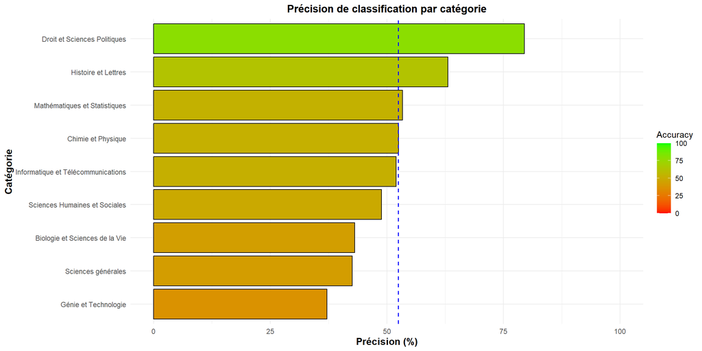

```r
# Créer un graphique de précision par catégorie
accuracy_by_class <- data.frame(
  Class = class_performance$Classe,
  Accuracy = class_performance$Taux_Reussite
)

# Trier par précision
accuracy_by_class <- accuracy_by_class[order(accuracy_by_class$Accuracy), ]
accuracy_by_class$Class <- factor(accuracy_by_class$Class,
                                   levels = accuracy_by_class$Class)

# Créer le graphique
ggplot(accuracy_by_class, aes(x = Class, y = Accuracy, fill = Accuracy)) +
  geom_bar(stat = "identity", color = "black", size = 0.5) +
  scale_fill_gradient(low = "red", high = "green", limits = c(0, 100)) +
  geom_hline(yintercept = mean(accuracy_by_class$Accuracy),
             linetype = "dashed", color = "blue", size = 0.7) +
  coord_flip() +
  theme_minimal() +
  theme(
    axis.title = element_text(size = 12, face = "bold"),
    plot.title = element_text(size = 13, hjust = 0.5, face = "bold"),
    legend.position = "right"
  ) +
  ggtitle("Précision de classification par catégorie") +
  xlab("Catégorie") +
  ylab("Précision (%)") +
  ylim(0, 100)
```

- **Résumé des résultats :**

```r
cat("Nombre total de thèses traitées :", nrow(df_lda), "\n")
```

```
## Nombre total de thèses traitées : 5000
```

```r
cat("Nombre de catégories :", length(unique(df_lda$Subject)), "\n")
```

```
## Nombre de catégories : 9
```

```r
cat("Nombre de features TF-IDF :", ncol(X), "\n")
```

```
## Nombre de features TF-IDF : 200
```

```r
cat("Nombre d'axes discriminants utilisés pour le Bayésien :", ncol(df_lda) - 1, "\n\n")
```

```
## Nombre d'axes discriminants utilisés pour le Bayésien : 8
```

```r
cat("Accuracy globale :", round(cv_accuracy * 100, 2), "%\n")
```

```
## Accuracy globale : 49.52 %
```

```r
cat("Kappa :", round(cv_kappa, 3), "\n\n")
```

```
## Kappa : 0.402
```

```r
# Calculer les meilleures et pires catégories
best_idx <- which.max(class_performance$Taux_Reussite)
worst_idx <- which.min(class_performance$Taux_Reussite)

cat("Meilleure catégorie :", class_performance$Classe[best_idx],
    " (", class_performance$Taux_Reussite[best_idx], "%)\n")
```

```
## Meilleure catégorie : Droit et Sciences Politiques  ( 79.49 %)
```

```r
cat("Catégorie la plus difficile :", class_performance$Classe[worst_idx],
    " (", class_performance$Taux_Reussite[worst_idx], "%)\n\n")
```

```
## Catégorie la plus difficile : Génie et Technologie  ( 37.17 %)
```

```r
cat("Nombre moyen de thèses par catégorie :", round(mean(class_performance$Total), 1), "\n")
```

```
## Nombre moyen de thèses par catégorie : 555.6
```

Ce que l’on peut conclure de ces résultats, c’est que par exemple les disciplines comme le “Droit et Sciences Politiques” ou encore l’Histoire ont une meilleure précision que les autres disciplines, surement car ce sont des disciplines qui utilisent un vocabulaire très spécifiques comme par exemple “lois, siècles, époques etc…”.

Les autres disciplines un peu plus scientifique sont un peu plus compliquée à prédire car les mots se ressemblent, c’est à la fois des mathématiques ou de la physique ce qui complique les choses pour le modèle.

### 4. Conclusion

Ce projet nous a donc permis d’utiliser différentes méthodes de traitement de textes pour résoudre un problème : classer automatiquement des thèses de doctorat par discipline.

Pour cela nous avons suivi trois grandes étapes.

Tout d’abord nous avons traité les textes en les nettoyant et en utilisant la métjode de TF-IDF afin de transformer les mots en valeur numériques.

Ensuite nous avons utillisé l’AFD. Cette méthode a permis de réduire le nombre de variables tout en séparant du mieux possible les différentes disciplines.

Et enfin, nous avons appliqué un classifieur Bayésien naïf en utilisant les axes fournis par l’AFD afin de prédire au mieux chaque thèse.

Nous avons ensuite réalisée une validation croisée, et on a obtenu une précision d’environ 50%. Ce résultat est satisfaisant contenu de la difficulté du problème (9 disciplines proches les unes des autres).

Grâce à ce projet on a pu comprendre comment allier les méthodes de réduction de dimension et la classification afin de créer un modèle performant.